# Ford Go Bike Data for February 2019

## Dataset Overview

This dataset ("201902-fordgobike-tripdata.csv" file provided by Udacity) includes information about approximately 183,000 individual bike rides within the Ford Go Bike bike-sharing system in the greater San Francisco Bay area and San Jose during the month of February 2019. Additional information about the Ford Go Bike bike-sharing system can be found **[here](https://mtc.ca.gov/node/121741)**.  
Data rows containing inaccurate `member_birth_year` values, at least one NaN, high values for `duration_sec` (>9600 sec), or high values for `lin_distance` between the starting and ending station were dropped during initial data analyses to obtain a "cleaned" working dataset of 174,503 bike ride entries.

```
<class 'pandas.core.frame.DataFrame'>
Int64Index: 174503 entries, 4 to 183411
Data columns (total 21 columns):
 #   Column                   Non-Null Count   Dtype
---  ------                   --------------   -----
 0   duration_sec             174503 non-null  int64
 1   start_time               174503 non-null  datetime64[ns]
 2   end_time                 174503 non-null  datetime64[ns]
 3   start_station_id         174503 non-null  float64
 4   start_station_name       174503 non-null  object
 5   start_station_latitude   174503 non-null  float64
 6   start_station_longitude  174503 non-null  float64
 7   end_station_id           174503 non-null  float64
 8   end_station_name         174503 non-null  object
 9   end_station_latitude     174503 non-null  float64
 10  end_station_longitude    174503 non-null  float64
 11  bike_id                  174503 non-null  int64
 12  user_type                174503 non-null  object
 13  member_birth_year        174503 non-null  float64
 14  member_gender            174503 non-null  object
 15  bike_share_for_all_trip  174503 non-null  object
 16  log10_duration           174503 non-null  float64
 17  lin_distance             174503 non-null  float64
 18  rider_age                174503 non-null  float64
 19  start_time_hr            174503 non-null  int64
 20  start_time_dotw          174503 non-null  int64
dtypes: datetime64[ns](2), float64(10), int64(4), object(5)
memory usage: 29.3+ MB
```

## Distribution of Bike Ride Durations (Figure 1)

Because bike ride duration is the main "outcome" variable of interest, initial univariate analyses of `duration_sec` data and its log10-transformed data, `log10_duration`, were performed. After having filtered out the 376 bike rides >9600 sec in duration, the right-skewed `duration_sec` data (Figure 1, left) contained no extreme outliers and the log10-transformed data showed a unimodal and fairly symmetric distribution (Figure 1, right). Thus, duration data was further analyzed as a whole given that there was no obvious delineation between a low-duration group(s) and a high-duration group(s).  
('Down' arrow to view Sub-Slide)

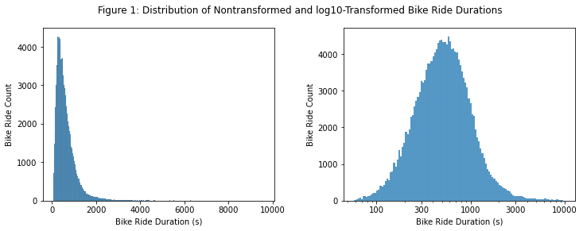

## Distributions of Bike Ride Starting Hour and Starting Day of the Week (Figure 2)

Interestingly, univariate distributions of bike ride `start_time_hr` and `start_time_dotw` (day of the week) values clearly showed bike ride frequencies that peaked at traditional workday start (hour 8; 8 am) and end (hour 17; 5 pm) hours (Figure 2, left) and that were around two times more frequent on each traditional work day (Monday through Friday) compared to each weekend day (Saturday and Sunday) (Figure 2, right).

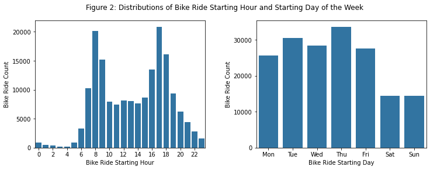

## Distribution of Bike Rider Ages (Figure 3)

The univariate distribution of `rider_age` (Figure 3) also showed an elevated number of bike rides by "working age" individuals who probably are more likely to bike to work, i.e., approximately 25-36 years of age.

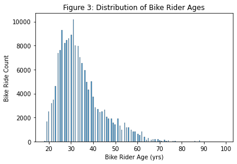

## Distribution of Bike Ride Start-to-End Station Distances (Figure 4)

This final univariate distribution of `lin_distance` (linear distance between start and end station) showed a "zero linear distance" subpopulation of bike rides (i.e., "round trip" bike rides starting and ending at the same station) along with a right-skewed "nonzero linear distance" subpopulation of bike rides (Figure 4), the latter of which after log10 transformation displayed a relatively unimodal and symmetric distribution (data not shown). Also, only a small number of bike rides involve a start-to-end station distance between 8 and 16 km.

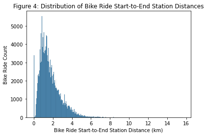

## Conclusions from Univariate Analyses:

> The preceding univariate analyses suggest the presence among the Ford Go Bike system riders of:  
> (a) a subpopulation of "work commuter" bikers (Figure 2 and 3), and  
> (b) some other subpopulation of zero-distance "recreational, round trip" bikers (Figure 4).

## Average Duration vs. Starting Hour and vs. Starting Day of the Week (Figure 5)

An initial bivariate scatterplot of `duration_sec` vs. `start_time_hr` suggested an increased number of longer duration bike rides during the midday hours (roughly 10 am to 5 pm) (data not shown). To avoid the overplotting associated with the initial scatterplot, the average bike ride duration was plotted across the starting hours of the bike rides (Figure 5, left). The variability in early morning hour (hour 0 to 5) bike ride durations makes it difficult to confidently state that a peak in duration occurs at hour 2 (2 am); however, there is a clear increase in bike ride duration during the "midday" hours of hour 11 (11 am) through hour 15 (3 pm). Similarly, the average bike ride duration was plotted across the starting day of the week for the bike rides (Figure 5, right), and this showed an increased average duration on the weekend days, Saturday and Sunday. Overall, these results are potentially unexpected given the apparently prominent work commuter subpopulation, which might not be expected to take longer bike rides during the midday hours or on the weekend days.

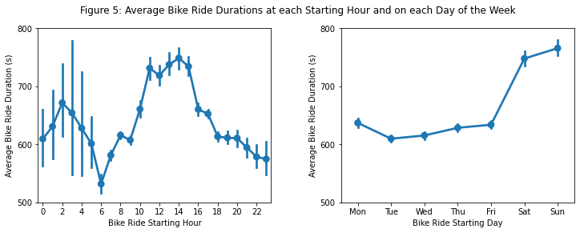

## Bike Ride Duration for both User Types (Figure 6)

Interestingly, the most apparent difference in bike ride duration involved the "Subscriber" compared to the "Customer" user type, based on both the median (Figure 6, left; plotted using `log10_duration` to better distribute y-axis values) and the average (Figure 6, right) bike ride duration.

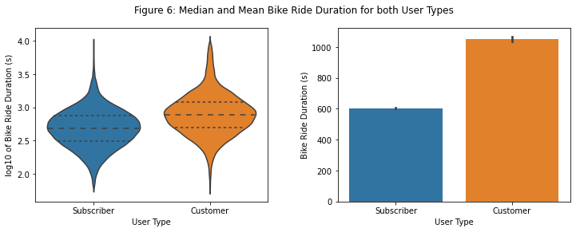

## Distributions of Bike Ride Starting Hour and Starting Day of the Week for both User Types (Figure 7)

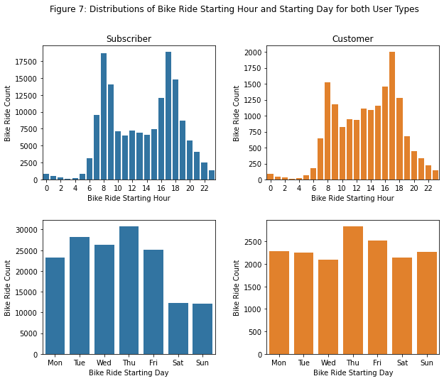

## Conclusions from Bivariate Analyses:

> The overall average bike ride durations are increased during the midday hours and on the weekend days (Figure 5).  
> The median and average bike ride durations are increased for "Customer" riders compared to "Subscriber" riders (Figure 6).  
> Consistent with the increases in overall average bike ride duration during the midday hours and on the weekend days (Figure 5), the relatively longer-duration Customer bike rides (Figure 6) were relatively elevated in number during the midday hours (Figure 7, top row) and weekend days (Figure 7, bottom row) compared to that of Subscribers, who bike more around peak workday start (hour 8; 8 am) and end (hour 17; 5 pm) hours and on traditional work week days.

## Duration versus Starting Hour for each User Type across the Starting Days of the Week (Figure 8)

Because the above analyses indicated that bike ride durations and counts were markedly influenced by start time and user type features, multivariate pointplots of average `duration_sec` vs. `start_time_hr` separated by user type (Subscriber or Customer) and faceted across the days of the week (`start_time_dotw`) were generated (Figure 8). These plots clearly showed longer duration Customer bike rides (on average) during the non-"early morning" hours, particularly on the weekend days. With the five times greater number of Subscriber than Customer weekend rides (Figure 7), the modestly longer average duration of Subscriber bike rides on Saturday and Sunday, including elevated midday durations, also contribute to the previously discussed overall (bivariate) increased average bike ride durations during the midday and on Saturday and Sunday (Figure 5).

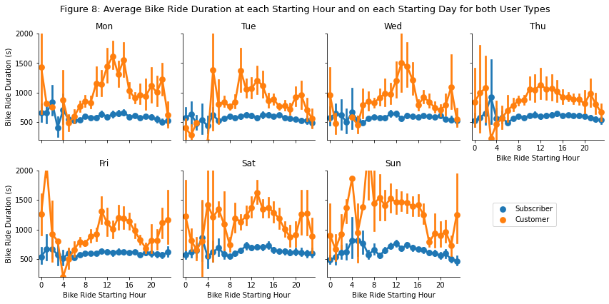

## Duration versus Start-to-End Station Distance for each User Type (Figure 9)

The above distribution of start-to-end station distances showed a small, zero-distance subpopulation and a large, nonzero-distance subpopulation of bike rides (Figure 4). Looking further at the relationship between the outcome variable of interest, bike ride duration (`duration_sec`), and start-to-end station distance (`lin_distance`), it can be seen that the majority of nonzero-distance data points compose a positively-sloped "linear cluster" (Figure 9). These data points are consistent with a purposeful ride from one location to another, such as that by a work commuter. Also present was a second "recreational" grouping of longer-duration bike rides of zero or short (< 4 km) linear distance that are graphically to the left of and above the linear cluster (Figure 9). Along with the violinplot of `user_type` vs. `log10_duration`(Figure 6), this plot shows a modestly greater proportion of Customer rides falling in the so-called longer-duration "recreational" grouping (to the left of and above the "purposeful" linear cluster of rides). Conversely, this indicates that a greater proportion of Subscriber rides fell within the "purposeful" linear cluster.

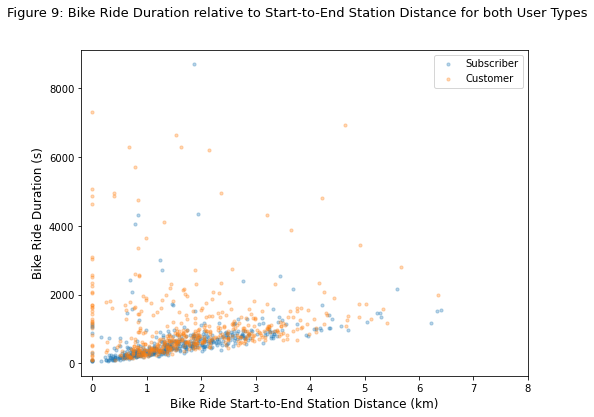

## Duration versus Start-to-End Station Distance relative to Average Rider Age (Figure 10)

Considering whether "working age" riders, rather than younger or older riders, tend to more often fall within the linear cluster of the `duration` vs. `lin_distance` plot, a 2D Heatmap of `duration` vs. `lin_distance` with sequential coloring of the average rider age within each grid bin was generated. Interestingly, there did appear to be a solid presence of working age riders (early to mid-30s) on average within the linear cluster and more of a variety of younger (more yellow) and older (more blue) riders on average associated with rides "above" the linear cluster. However, the wide ranging number of bike rides in the various 2D Heatmap grid bins suggests a need for caution in the interpretation of the pattern of these color-encoded average ages.

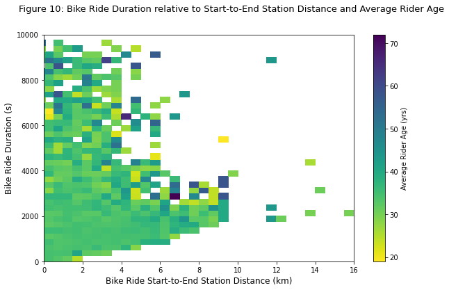

## Conclusions:

> Figure 8: Longer duration bike rides (on average) are taken by "Customers" compared to "Subscribers" during most non-"early morning" hours, particularly the midday hours, for all days of the week. Longer-duration Customer rides are generally more prevalent on weekend days (Saturday and Sunday), with an apparent modest increase in midday bike ride durations for Subscribers on the weekend days as well.  
> Figure 9: A greater proportion of longer-duration Customer bike rides fall into the so-called "recreational" data points (to the left of and above the linear cluster of data points). Conversely, a greater proportion of Subscriber bike rides fall into the "purposeful" linear cluster of data points, which are likely to include work commuter riders.  
> Figure 10: The average ages of bikers taking rides that fall in the "purposeful" linear cluster are consistent with that of working age individuals who might be expected to bike to work (i.e., predominantly early to mid-30s on average). Conversely, a wider variety of younger (more yellow) and older (more blue) riders on average appear to be associated with "recreational" rides above the linear cluster.